# Labo 5

Oscar Centeno Mora

# Análisis de Discriminación (EFA)

EL presente laboratorio expone la técnica de LDA y QDA. Se presenta:

1. Funciones y librerías del DA
2. Estadísticas descriptivas y supuestos DA
3. Partición de los datos
4. Estimación de los modelos lda y qda
5. Análisis reglas de discriminación
6. Gráficos de partición y proyección
7. Tablas de confusión
8. Nuevos casos sin categoría de pertenencia.

## Sitios web de referencia

Los siguientes enlaces son referentes a la aplicación del FA exploratorio en R:

https://rpubs.com/Joaquin_AR/233932 https://rpubs.com/shpotes/277311 https://www.ecured.cu/Analisis_discriminante_en_R http://halweb.uc3m.es/esp/Personal/personas/jmmarin/esp/DM/tema1dm.pdf https://www.statmethods.net/advstats/discriminant.html https://rpubs.com/Nolan/298913 https://rpubs.com/ifn1411/LDA https://rstudio-pubs-static.s3.amazonaws.com/35817_2552e05f1d4e4db8ba87b334101a43da.html https://github.com/avrilcoghlan/LittleBookofRMultivariateAnalysis/blob/master/src/multivariateanalysis.rst

## Datos del laboratorio

### Iris

Trabajamos con la más famosa base de datos en el mundo de la analítica: iris. Esta contiene mediciones de 150 flores iris de tres especies diferentes.

Las tres clases del conjunto de datos Iris:

Iris-setosa (n = 50) Iris-versicolor (n = 50) Iris-virginica (n = 50) Las cuatro características del conjunto de datos Iris:

-Longitud del sepal en cm -Ancho sepal en cm -Longitud del pétalo en cm -Anchura del pétalo en cm.

```r
datatable(iris)
```

|  | Sepal.Length | Sepal.Width | Petal.Length | Petal.Width | Species |
| --- | --- | --- | --- | --- | --- |
| 1 | 5.1 | 3.5 | 1.4 | 0.2 | setosa |
| 2 | 4.9 | 3 | 1.4 | 0.2 | setosa |
| 3 | 4.7 | 3.2 | 1.3 | 0.2 | setosa |
| 4 | 4.6 | 3.1 | 1.5 | 0.2 | setosa |
| 5 | 5 | 3.6 | 1.4 | 0.2 | setosa |
| 6 | 5.4 | 3.9 | 1.7 | 0.4 | setosa |
| 7 | 4.6 | 3.4 | 1.4 | 0.3 | setosa |
| 8 | 5 | 3.4 | 1.5 | 0.2 | setosa |
| 9 | 4.4 | 2.9 | 1.4 | 0.2 | setosa |
| 10 | 4.9 | 3.1 | 1.5 | 0.1 | setosa |

[output cut: 140 more lines]

### banknote

Se pretende generar un modelo discriminante que permita diferenciar entre billetes verdaderos y falsos. Se han registrado múltiples variables para 100 billetes verdaderos y 100 billetes falsos:

-Status: si es verdadero (genuine) o falso (counterfeit). -Length: longitud (mm) -Left: Anchura del borde izquierdo (mm) -Right: Anchura del borde derecho (mm) -Bottom: Anchura del borde inferior (mm) -Top: Anchura del borde superior (mm) -Diagonal: longitud diagonal (mm)

```r
data(banknote)
levels(banknote$Status)
```

```
## [1] "counterfeit" "genuine"
```

```r
datatable(banknote)
```

|  | Status | Length | Left | Right | Bottom | Top | Diagonal |
| --- | --- | --- | --- | --- | --- | --- | --- |
| 1 | genuine | 214.8 | 131 | 131.1 | 9 | 9.7 | 141 |
| 2 | genuine | 214.6 | 129.7 | 129.7 | 8.1 | 9.5 | 141.7 |
| 3 | genuine | 214.8 | 129.7 | 129.7 | 8.7 | 9.6 | 142.2 |
| 4 | genuine | 214.8 | 129.7 | 129.6 | 7.5 | 10.4 | 142 |
| 5 | genuine | 215 | 129.6 | 129.7 | 10.4 | 7.7 | 141.8 |
| 6 | genuine | 215.7 | 130.8 | 130.5 | 9 | 10.1 | 141.4 |
| 7 | genuine | 215.5 | 129.5 | 129.7 | 7.9 | 9.6 | 141.6 |
| 8 | genuine | 214.5 | 129.6 | 129.2 | 7.2 | 10.7 | 141.7 |
| 9 | genuine | 214.9 | 129.4 | 129.7 | 8.2 | 11 | 141.9 |
| 10 | genuine | 215.2 | 130.4 | 130.3 | 9.2 | 10 | 140.7 |

[output cut: 190 more lines]

## Funciones y librerías del DA

Utilizaremos dos funciones: lda y qda.

### lda() (MASS)

La estructura es :

```r
# lda(x, …)
#  S3 method for formula
# lda(formula, data, …, subset, na.action)

# S3 method for default
# lda(x, grouping, prior = proportions, tol = 1.0e-4,
#    method, CV = FALSE, nu, …)

# S3 method for data.frame
# lda(x, …)

#  S3 method for matrix
#  lda(x, grouping, …, subset, na.action)
```

Ver el enlace: https://www.rdocumentation.org/packages/MASS/versions/7.3-51.1/topics/lda

### qda()

La estructura es :

```r
# qda(x, …)
#  S3 method for formula
# qda(formula, data, …, subset, na.action)

# S3 method for default
# qda(x, grouping, prior = proportions,
#     method, CV = FALSE, nu, …)

#  S3 method for data.frame
#  qda(x, …)

# S3 method for matrix
#  qda(x, grouping, …, subset, na.action)
```

Ver el enlace: https://www.rdocumentation.org/packages/MASS/versions/7.3-51.1/topics/qda

## Estadísticas descriptivas y pruebas de supuestos

### Datos iris

#### Análisis de densidades por especie y variables

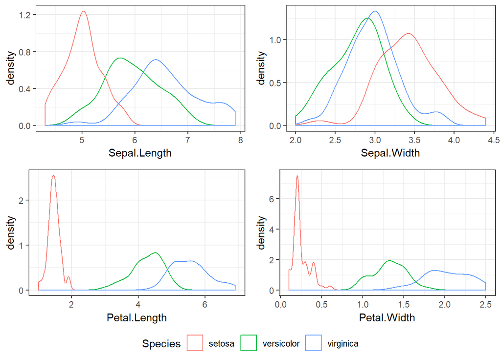

#### Correlograma

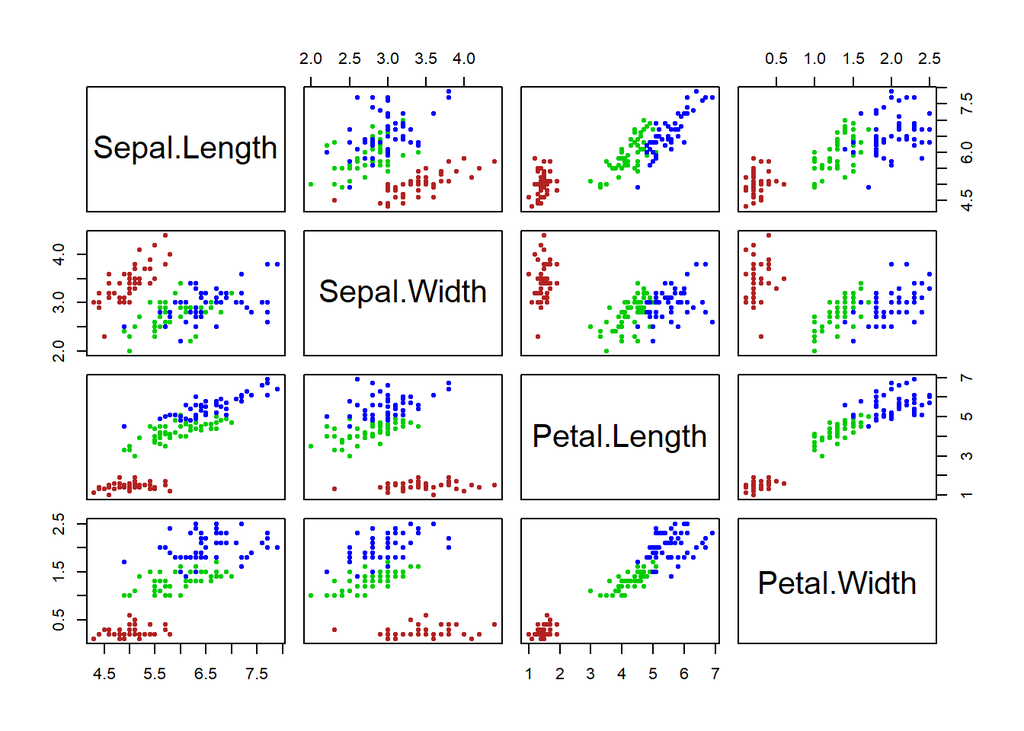

Las variables Petal.Lenght y Petal.Width son las dos variables con más potencial para poder separar entre clases. Sin embargo, están altamente correlacionadas, por lo que la información que aportan es en gran medida redundante.

#### Distribución de los predictores de forma individual

Distribución de los predictores de forma individual:

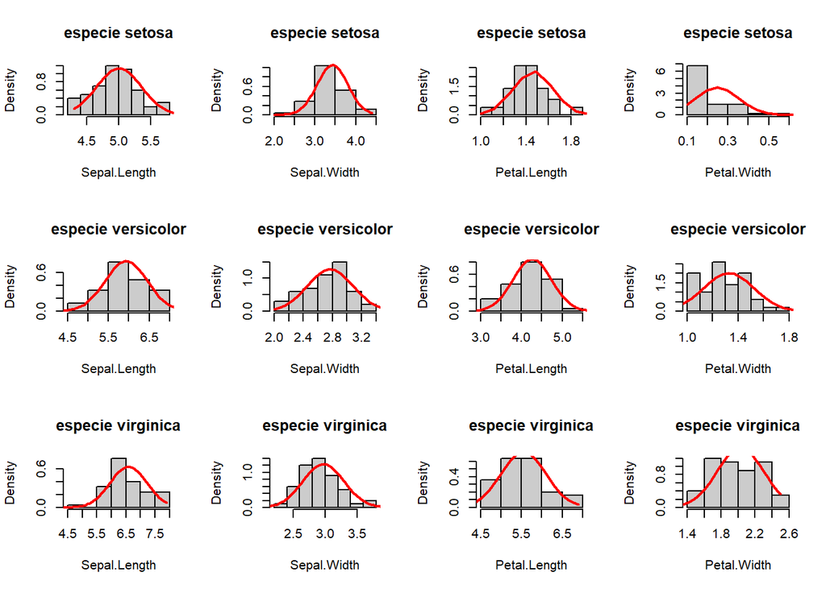

#### Normalidad por especie y variables

QQPlots

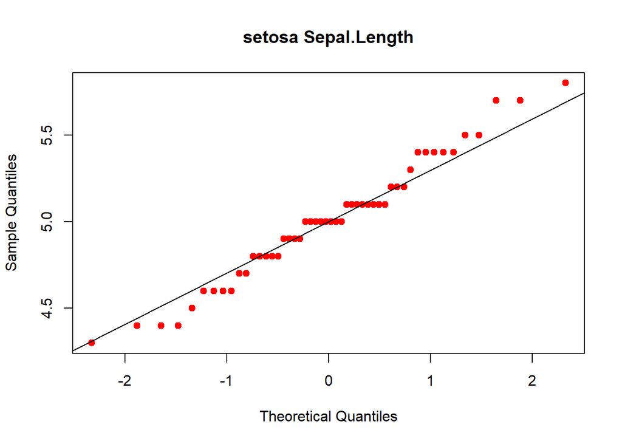

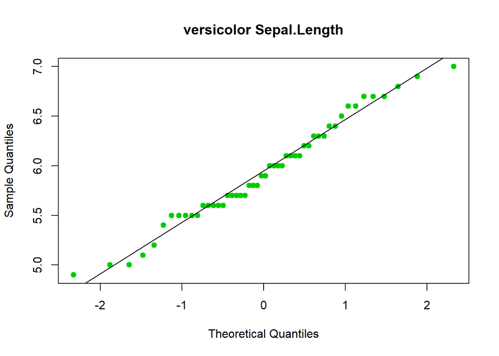

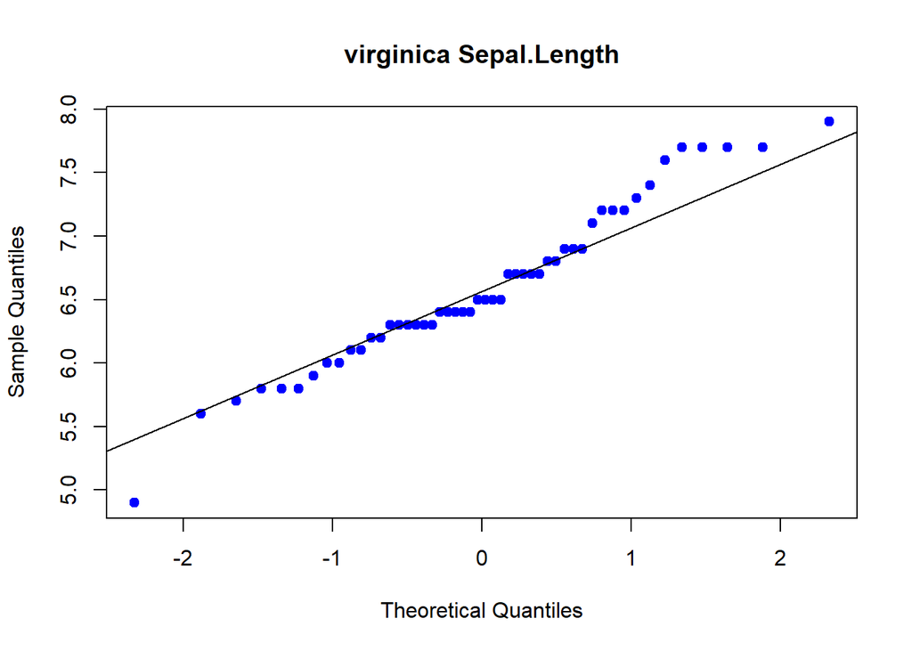

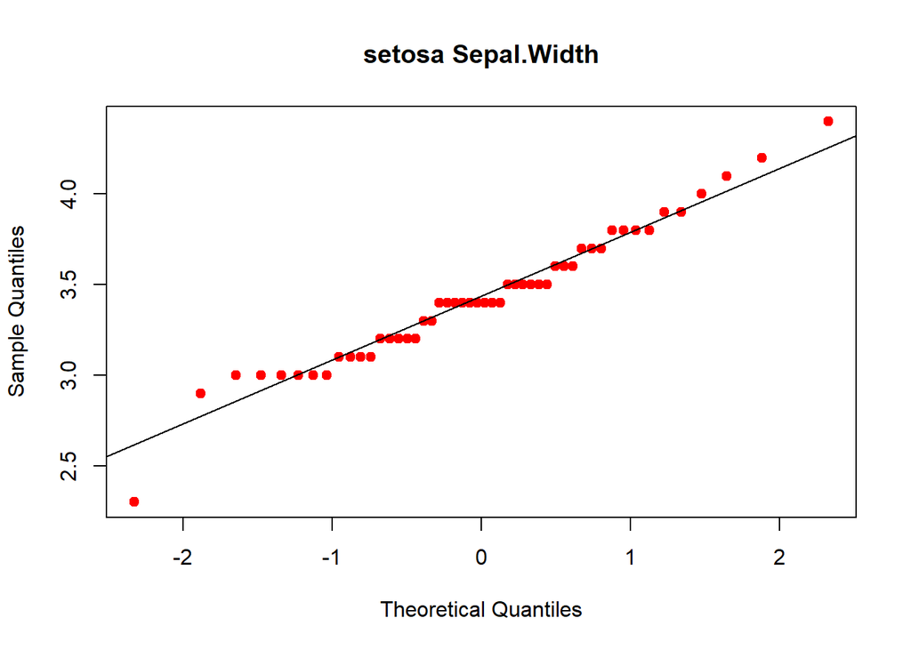

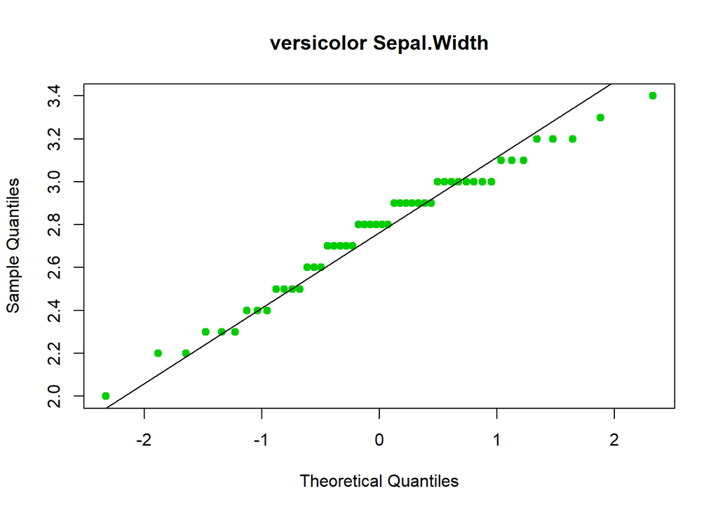

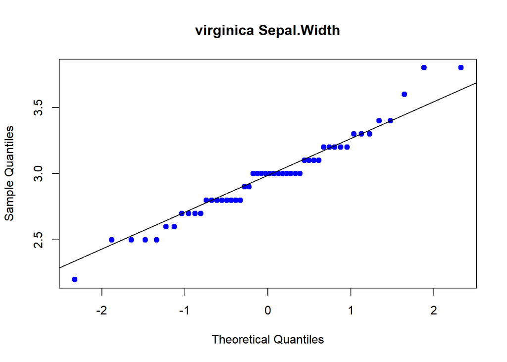

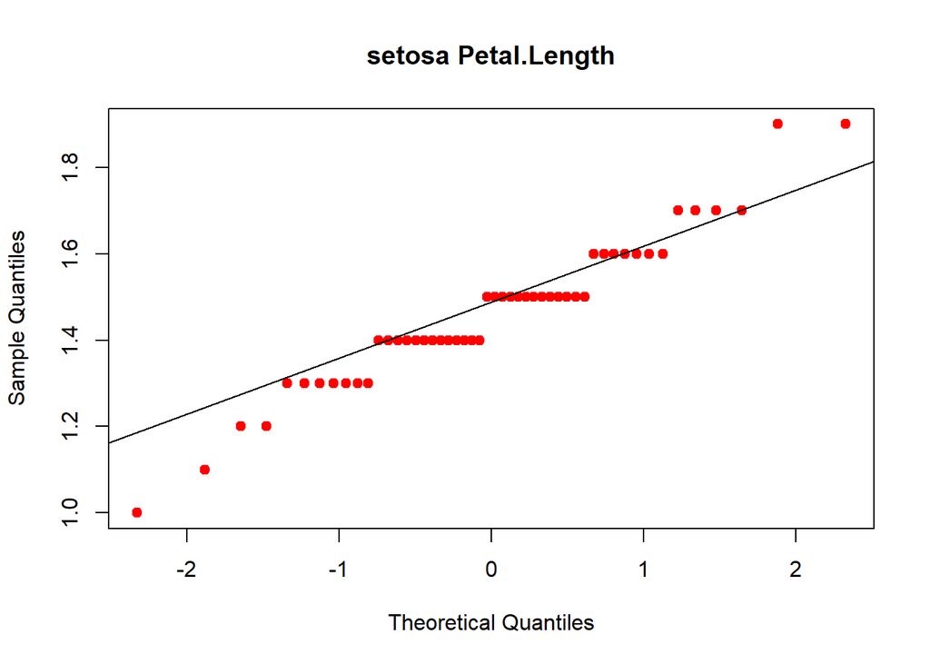

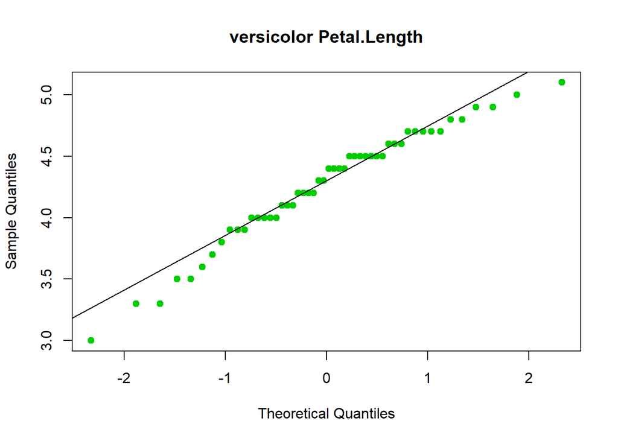

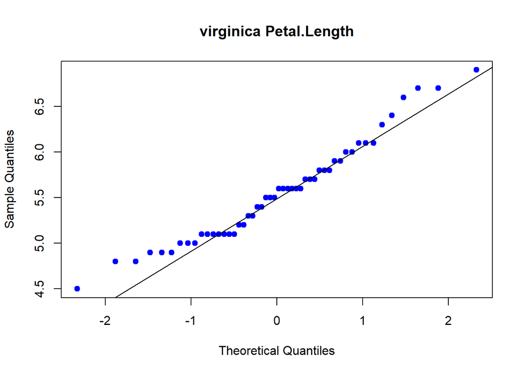

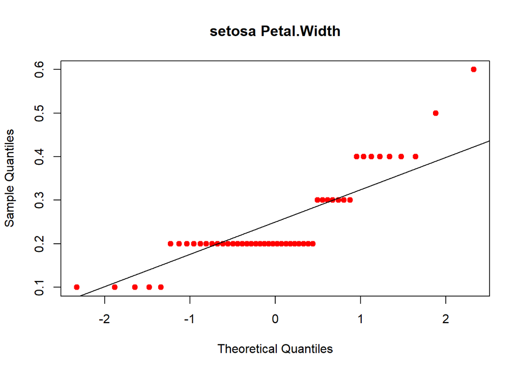

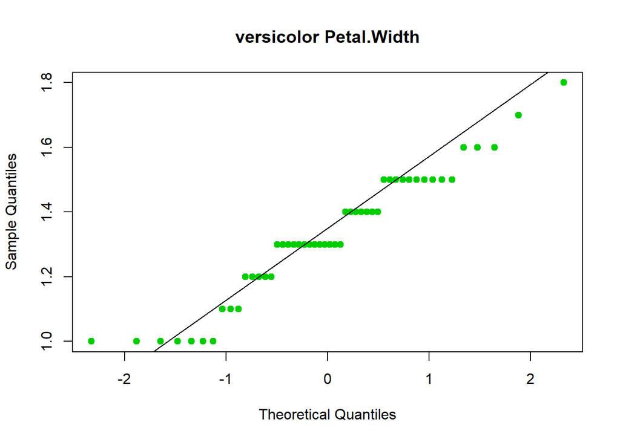

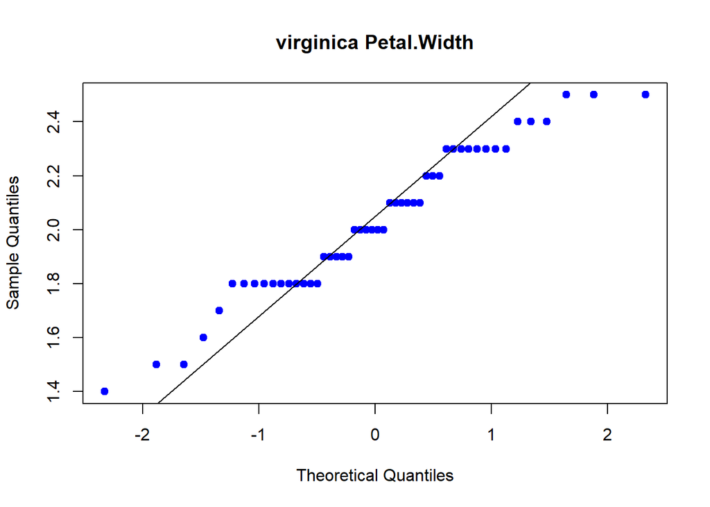

Pruebas de normalidad

| Species | variable | p_value_Shapiro.test |
| --- | --- | --- |
| setosa | Sepal.Length | 0.45951 |
| setosa | Sepal.Width | 0.27153 |
| setosa | Petal.Length | 0.05481 |
| setosa | Petal.Width | 0.00000 |
| versicolor | Sepal.Length | 0.46474 |
| versicolor | Sepal.Width | 0.33800 |
| versicolor | Petal.Length | 0.15848 |
| versicolor | Petal.Width | 0.02728 |
| virginica | Sepal.Length | 0.25831 |
| virginica | Sepal.Width | 0.18090 |
| virginica | Petal.Length | 0.10978 |
| virginica | Petal.Width | 0.08695 |

La variable petal.width no se distribuye de forma normal en los grupos setosa y versicolor.

#### Pruebas de outliers y Normalidad multivariantes

Busqueda de posibles outliers

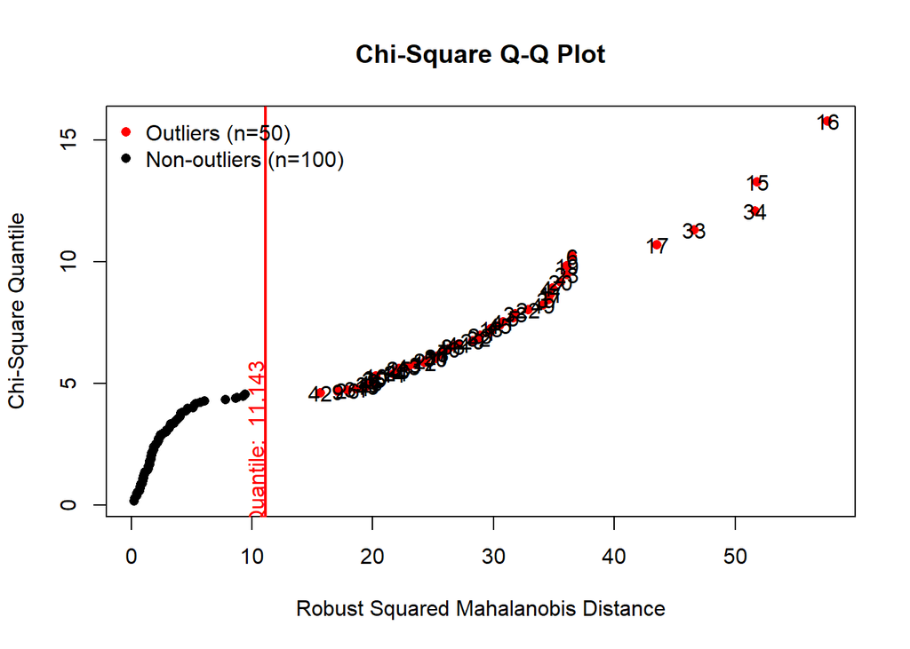

Normalidad conjunta

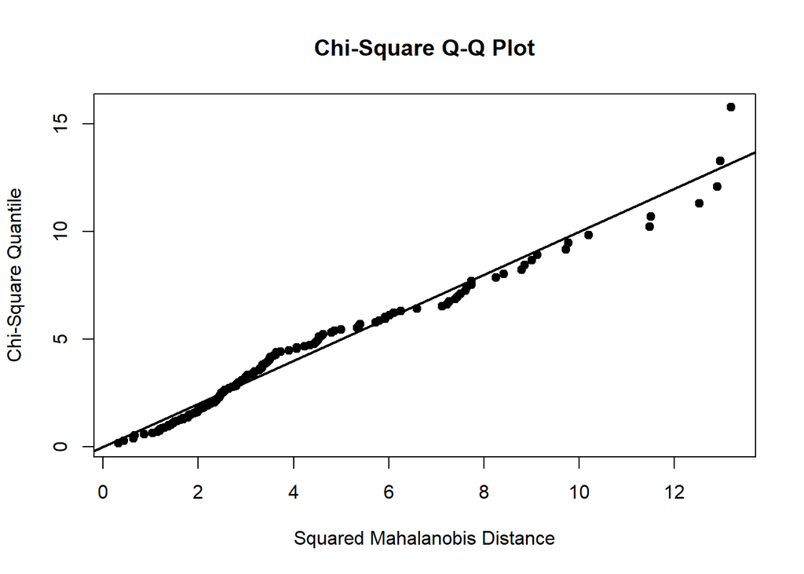

```
## $multivariateNormality
##      Test        H      p value MVN
## 1 Royston 50.39667 3.098229e-11  NO
##
## $univariateNormality
##           Test     Variable Statistic   p value Normality
## 1 Shapiro-Wilk Sepal.Length    0.9761  0.0102      NO
## 2 Shapiro-Wilk Sepal.Width     0.9849  0.1012      YES
## 3 Shapiro-Wilk Petal.Length    0.8763  <0.001      NO
## 4 Shapiro-Wilk Petal.Width     0.9018  <0.001      NO
##
## $Descriptives
##                n     Mean   Std.Dev Median Min Max 25th 75th       Skew
## Sepal.Length 150 5.843333 0.8280661   5.80 4.3 7.9  5.1  6.4  0.3086407
## Sepal.Width  150 3.057333 0.4358663   3.00 2.0 4.4  2.8  3.3  0.3126147
## Petal.Length 150 3.758000 1.7652982   4.35 1.0 6.9  1.6  5.1 -0.2694109
## Petal.Width  150 1.199333 0.7622377   1.30 0.1 2.5  0.3  1.8 -0.1009166
##                Kurtosis
## Sepal.Length -0.6058125
## Sepal.Width   0.1387047
## Petal.Length -1.4168574
## Petal.Width  -1.3581792
```

Prueba de normalidad de Royston

```
##      Test        H      p value MVN
## 1 Royston 50.39667 3.098229e-11  NO
```

Prueba de normalidad de Henze-Zirkler

```
##            Test       HZ p value MVN
## 1 Henze-Zirkler 2.336394       0  NO
```

Ambos test muestran evidencias significativas de falta de normalidad multivariante. El LDA tiene cierta robustez frente a la falta de normalidad multivariante, pero es importante tenerlo en cuenta en la conclusión del análisis.

#### Pruebas de homogeneidad

```
##
##  Box's M-test for Homogeneity of Covariance Matrices
##
## data:  iris[, -5]
## Chi-Sq (approx.) = 140.94, df = 20, p-value < 2.2e-16
```

El test Box’s M muestra evidencias de que la matriz de covarianza no es constante en todos los grupos, lo que a priori descartaría el método LDA en favor del QDA. Sin embargo, como el test Box’s M es muy sensible a la falta de normalidad multivariante, con frecuencia resulta significativo no porque la matriz de covarianza no sea constante sino por la falta de normalidad, cosa que ocurre para los datos de Iris. Por esta razón se va a asumir que la matriz de covarianza sí es constante y que LDA puede alcanzar una buena precisión en la clasificación. En la evaluación del modelo se verá como de buena es esta aproximación. Además, en las conclusiones se debe explicar la asunción hecha.

### Datos banknote

#### Análisis de los histogramas por variable y clasificación de los billetes

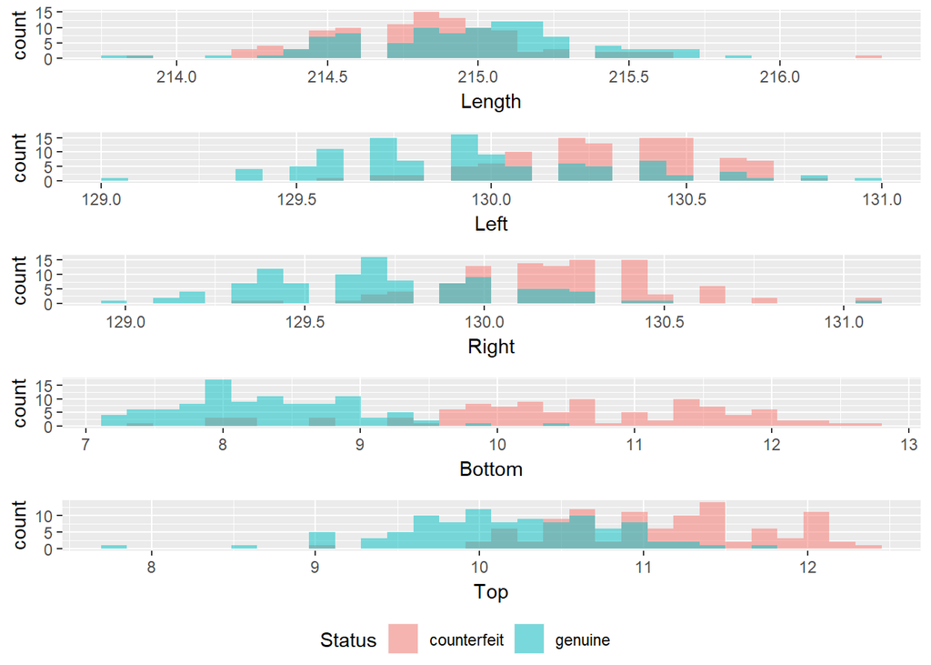

#### Autocorrelograma

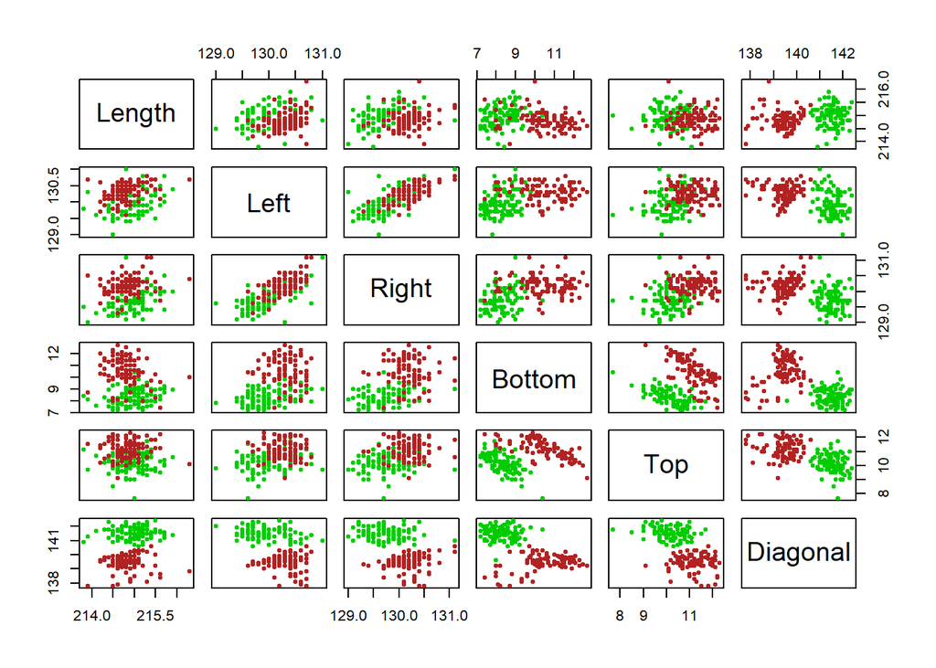

#### Otras distribuciones de frecuencia

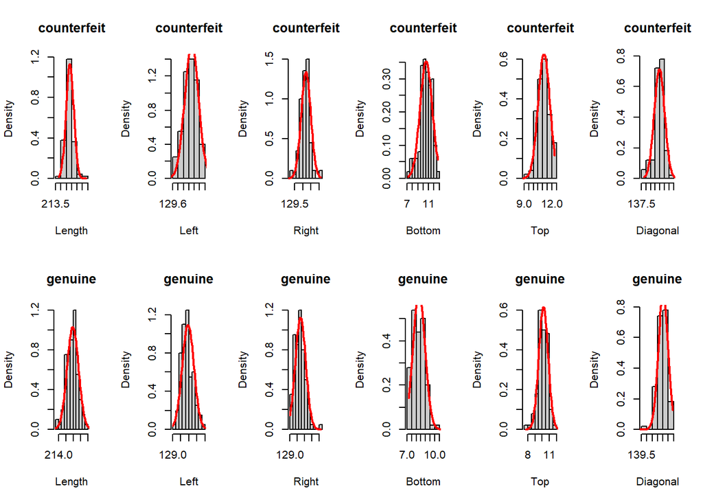

#### Representación de cuantiles normales de cada variable para cada tipo de billete

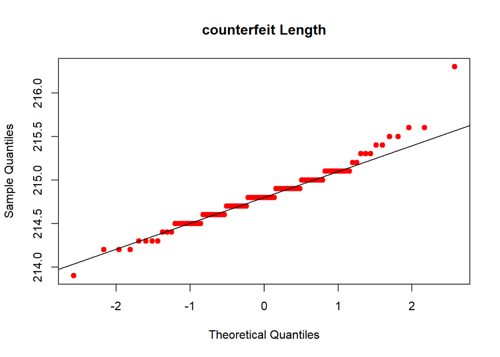

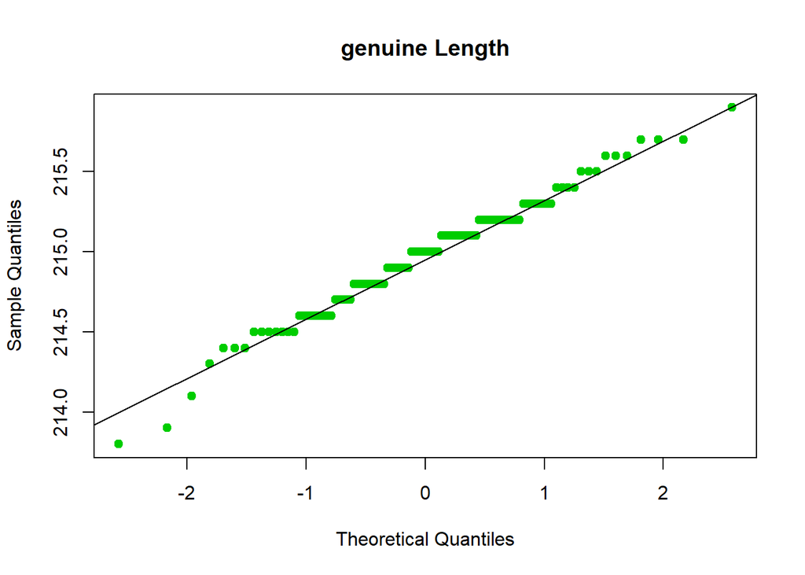

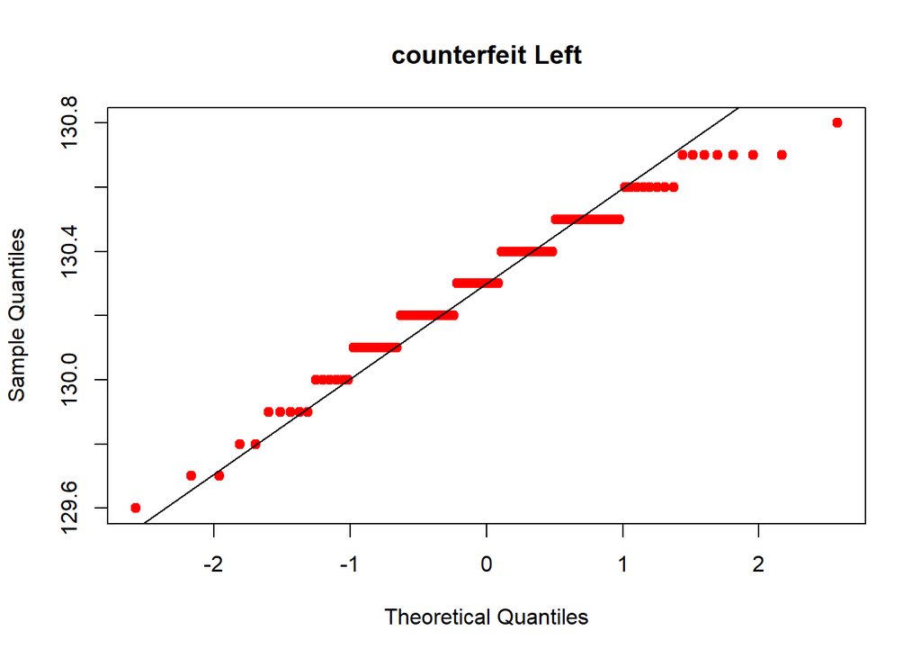

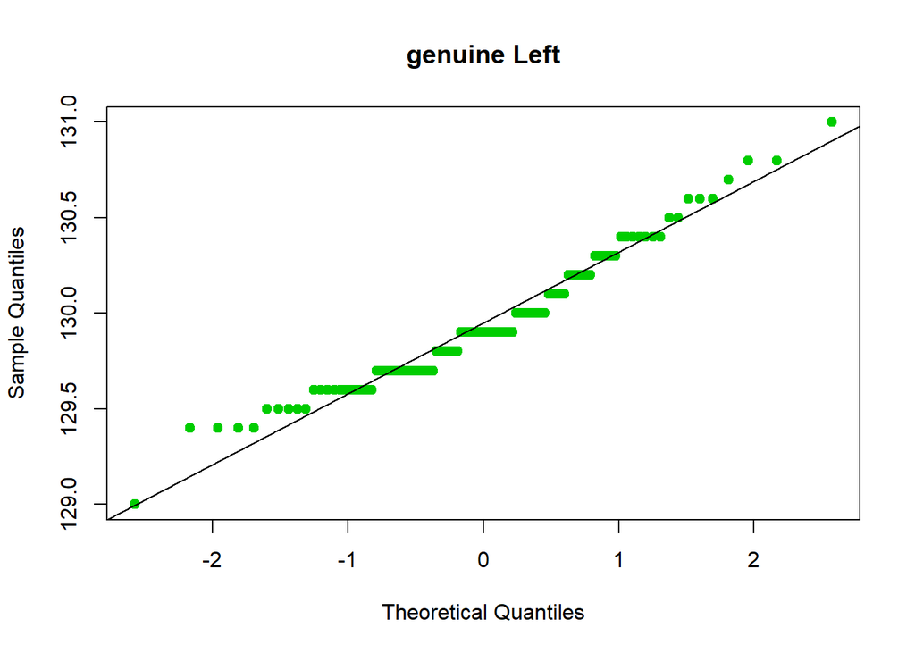

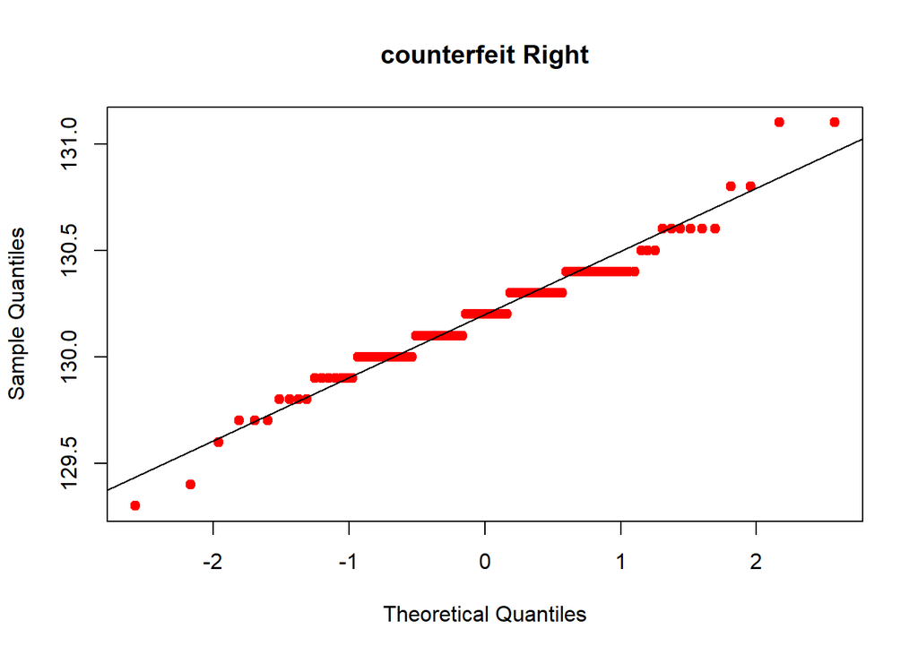

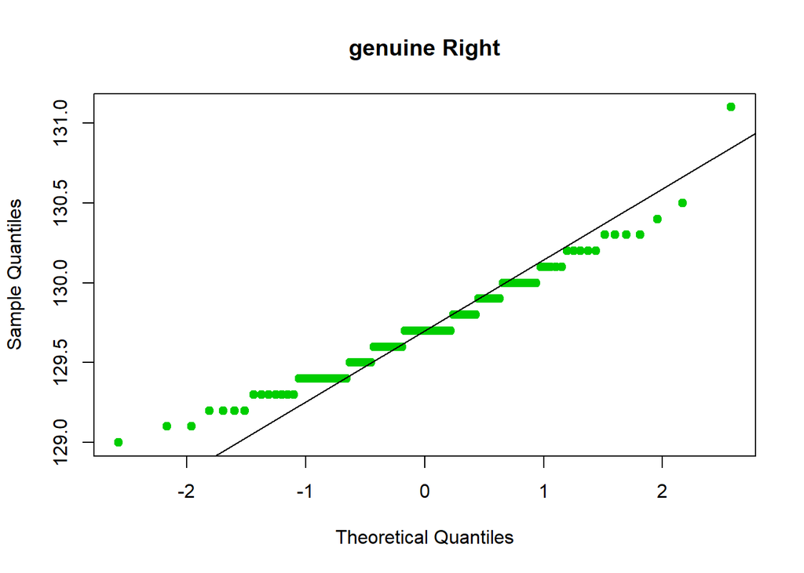

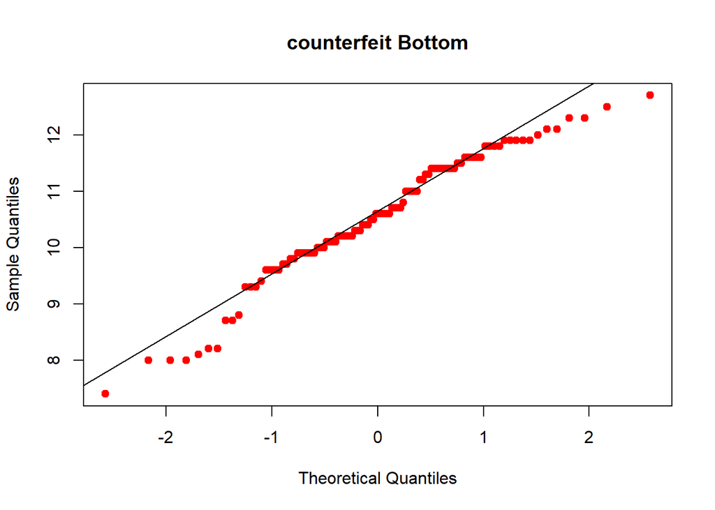

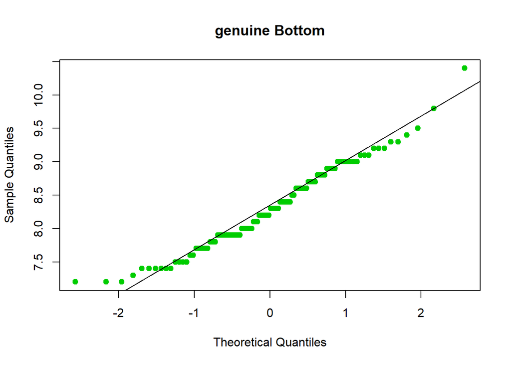

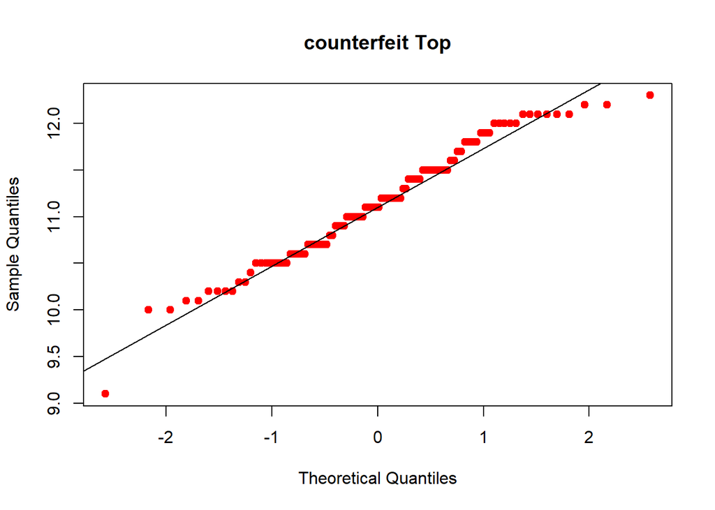

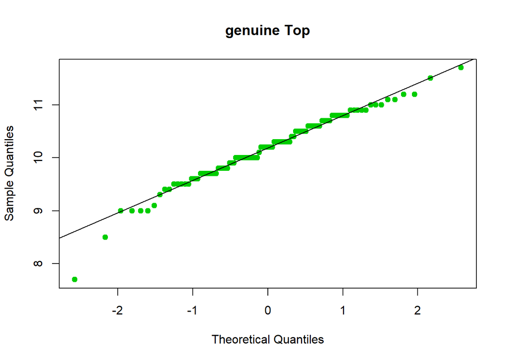

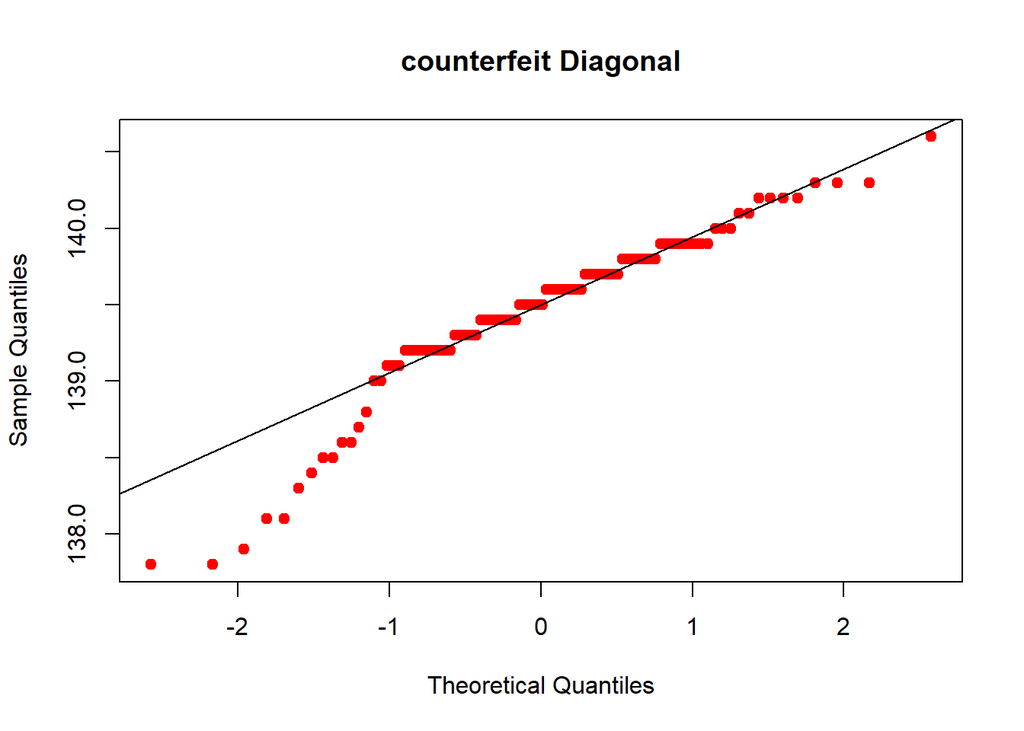

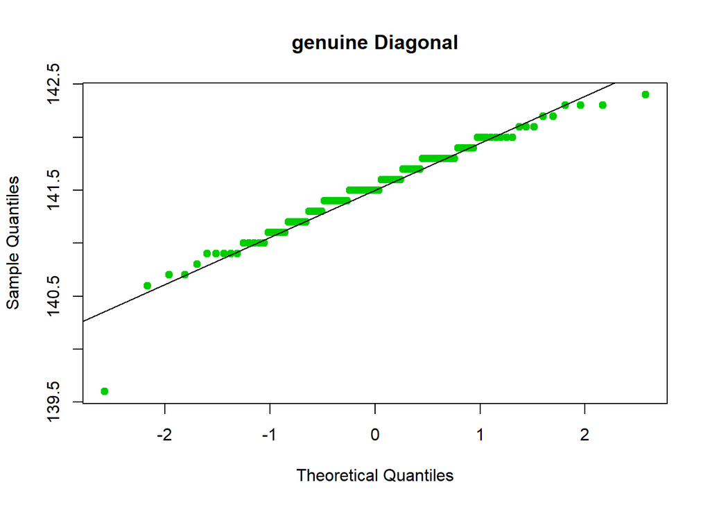